# Cross-over trials

Steve Simon

## Topics to be covered

- What you will learn
  - The paired t-test
  - The AB/BA cross-over
  - Period effects and carry-over
  - When should you use or not use a cross-over
  - Cross-over trials with a binary outcome
  - Cross-over trials with more than two treatments

## Pop quiz, true or false

1. Cross-over trials can only be used if the two treatments are drugs.
2. A paired t-test is a simple way to analyze a basic cross-over design.
3. A carry-over effect is easily accounted for and adjustments are relatively simple.
4. Cross-over trials should only be used if the disease being treated is acute, meaning that it does not persist over long periods of time.

Put your answers in the chat box as a sequence of T’s and F’s (e.g., TFFT).

## Quotations from two great philosophers

- “A man cannot step into the same river twice, because it is not the same river, and he is not same man.” - Heraclitus, 544 B.C.
- “You must unlearn what you have learned.” Yoda, 1980 A.D.

## Paired t-test data

[figure not shown]

## Descriptive statistics on wife’s age

| variable | mean | sd | n |
| --- | --- | --- | --- |
| wAge | 40.7 | 11.4 | 170 |

## Descriptive statistics on husband’s age

| variable | mean | sd | n |
| --- | --- | --- | --- |
| hAge | 42.6 | 11.6 | 199 |

## Descriptive statistics on age gap

| variable | mean | sd | n |
| --- | --- | --- | --- |
| age_gap | 2.2 | 4.1 | 170 |

## Paired t-test on couples ages

- Difference mean ($\bar{D}$) = 2.2
- Difference standard deviation ($S_D$) = 4.1
- Difference standard error ($S_D / \sqrt{n}$) = 0.3
- Test statistic $\Big(\frac{\bar{D}}{S_D/\sqrt{n}}\Big)$ = 7.15
- p<0.001

## Analyze as completely randomized block design

```
Analysis of Variance Table

Response: age
           Df Sum Sq Mean Sq F value    Pr(>F)
spouse      1    425  424.71  51.148 2.474e-11 ***
pair      169  43974  260.20  31.337 < 2.2e-16 ***
Residuals 169   1403    8.30
---
Signif. codes:  0 '***' 0.001 '**' 0.01 '*' 0.05 '.' 0.1 ' ' 1
```

## Restructured data for a completely randomized block design

[figure not shown]

## Mixed model/random coefficient analysis

- Uses long format
- Dependent variable: age
- Fixed effect: spouse
- Random intercept: pair

## Break #1

- What you have learned
  - The paired t-test
- What’s coming next
  - The AB/BA cross-over

## Parallel groups versus the AB/BA cross-over

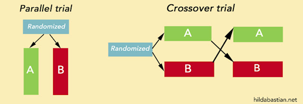

https://statistically-funny.blogspot.com/2021/03/in-clinical-trials-you-can-have-it-both.html

Warning:

- Try to use the term “treatment” and not “drug”.
  - Cross-over trians not limited to just drugs

## Why do you need both orders?

- Can you use just AB or BA?
  - Yes, but…
  - Important unanswered questions
  - “A man cannot step into the same river twice”

## Do I have to randomize?

- No.
  - Balanced allocation is an alternative
  - Advantages and disadvantages

## Data layout

[figure not shown]

## Alternate data layout

[figure not shown]

## Descriptive statistics, period 1

| variable | mean<sup>1</sup> | sd | n |
| --- | --- | --- | --- |
| period1 | 312.3 | 82.8 | 13 |

<sup>1</sup> Larger values imply better outcomes

## Descriptive statistics, period 2

| variable | mean<sup>1</sup> | sd | n |
| --- | --- | --- | --- |
| period2 | 324.6 | 67.9 | 13 |

<sup>1</sup> Larger values imply better outcomes

## Descriptive statistics, period gap

| variable | mean<sup>1</sup> | sd | n |
| --- | --- | --- | --- |
| period_gap | 12.3 | 61.0 | 13 |

<sup>1</sup> Defined as period2 - period1

## Descriptive statistics, formoterol

| variable | mean<sup>1</sup> | sd | n |
| --- | --- | --- | --- |
| formoterol | 341.2 | 59.7 | 13 |

<sup>1</sup> Larger values imply better outcomes

## Descriptive statistics, salbutamol

| variable | mean<sup>1</sup> | sd | n |
| --- | --- | --- | --- |
| salbutamol | 295.8 | 82.9 | 13 |

<sup>1</sup> Larger values imply better outcomes

## Descriptive statistics, drug gap

| variable | mean<sup>1</sup> | sd | n |
| --- | --- | --- | --- |
| drug_gap | 45.4 | 40.6 | 13 |

<sup>1</sup> Defined as formoterol - salbutamol

## Analysis using a completely randomized block design

```
Analysis of Variance Table

Response: pef
          Df Sum Sq Mean Sq F value    Pr(>F)
treatment  1  13388 13388.5  16.250  0.001666 **
id        12 115213  9601.1  11.654 7.935e-05 ***
Residuals 12   9887   823.9
---
Signif. codes:  0 '***' 0.001 '**' 0.01 '*' 0.05 '.' 0.1 ' ' 1
```

## Break #2

- What you have learned
  - The AB/BA cross-over
- What’s coming next
  - Period effects and carry-over

## Accounting for period effects

- Improves precision
- Adjusts for imbalances
- Requires layout used for completely randomized block design

## Why might you see period effects

- Temporal trends
  - Learning/fatigue effect
  - Degenerative diseases, acute conditions
  - Seasonal effects
- Carry-over: Persistence of a treatment applied in one period in a subsequent period of treatment
  - Physical persistence
  - Curative effect

## Layout for asthma data

[figure not shown]

## Counts for layout data

| treatment | order | period | n |
| --- | --- | --- | --- |
| formoterol | for/sal | 1 | 7 |
| formoterol | sal/for | 2 | 6 |
| salbutamol | for/sal | 2 | 7 |
| salbutamol | sal/for | 1 | 6 |

## Period by order means

| order | period1_mean | period2_mean |
| --- | --- | --- |
| for/sal | 337 | 306 |
| sal/for | 283 | 346 |

## Period by order plot

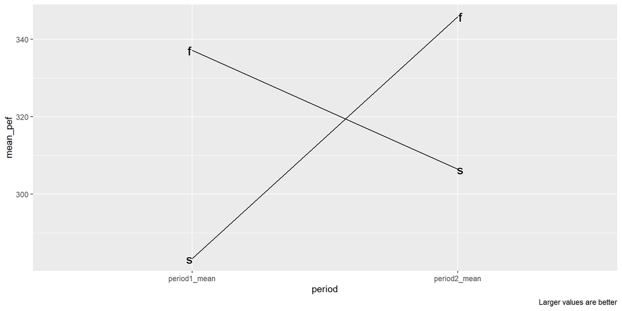

## What this graph would look like without a period effect

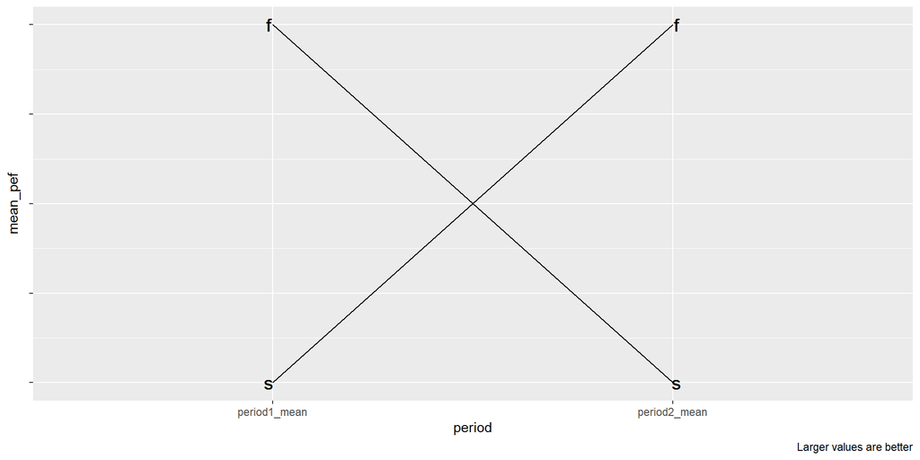

## Treatment by order means

| order | formoterol_mean | salbutamol_mean |
| --- | --- | --- |
| for/sal | 337 | 306 |
| sal/for | 346 | 283 |

## Treatment by order plot

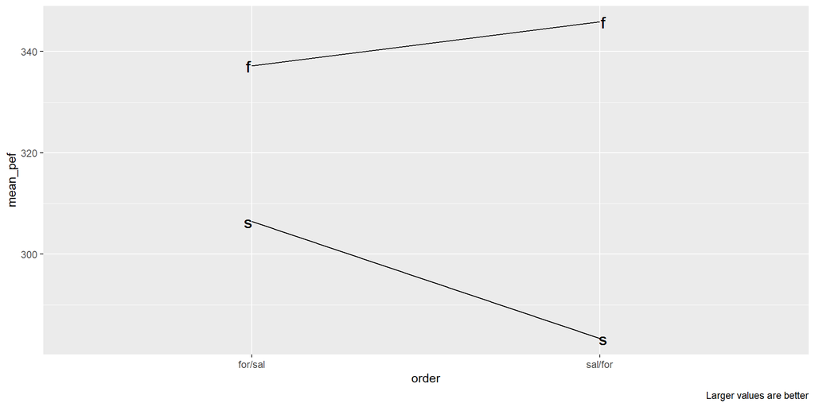

## What this graph would look like without a period effect

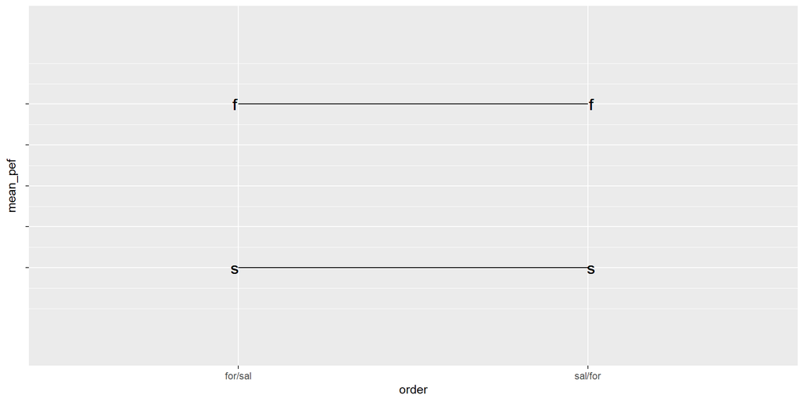

## Accounting for period effects

```
Analysis of Variance Table

Response: pef
          Df Sum Sq Mean Sq F value    Pr(>F)
order      1    335   335.2  0.4467  0.517697
id        11 114878 10443.5 13.9171 6.495e-05 ***
period     1    985   984.6  1.3121  0.276323
treatment  1  14036 14035.9 18.7044  0.001205 **
Residuals 11   8254   750.4
---
Signif. codes:  0 '***' 0.001 '**' 0.01 '*' 0.05 '.' 0.1 ' ' 1
```

## Details on the period model

- id is nested within order
- id is a random effect
  - Test of order should be MS(order)/MS(id)
- Use partial (Type III) sums of squares if unbalanced

## Break #3

- What you have learned
  - Period effects and carry-over
- What’s coming next
  - When should you use or not use a cross-over

## Systematic overview of parachute use

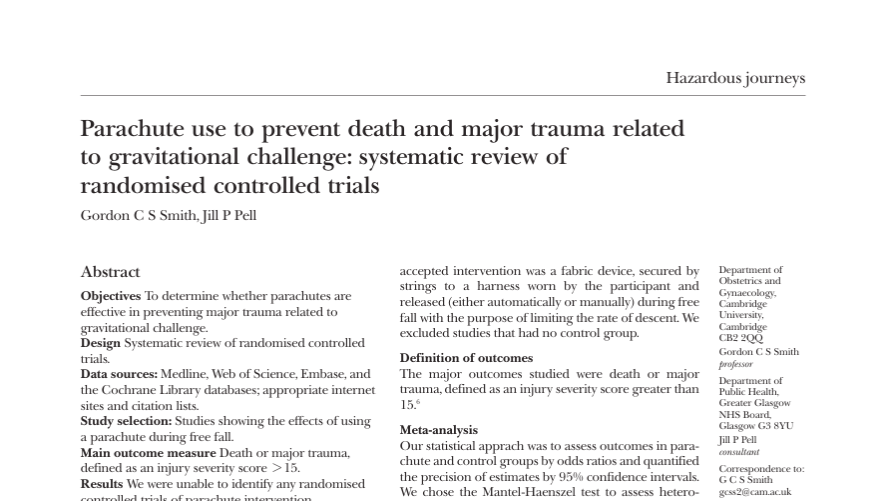

## When you cannot use a cross-over trial

- Acute conditions
- Mortality and other irreversible events
- Training/education
- Irreversible treatments
- Persistent effects

## When you can use a cross-over trial

- Chronic conditions
- Short-term benefits
- Adequate wash-out period
  - Drugs with a short half-life

## Practical and ethical concerns

- Can you ask a patient to endure two treatments?
- Do you have enough time to run two treatments in succession?
- Can you leave the patient untreated during the wash-out period?

## What is you have a carry-over effect?

- No easy answer
  - Adjustments have poor power
  - Between subject comparison
- Unclear where to make adjustments
  - Active treatment versus placebo:
    - Assign the carry-over to placebo
  - Two active treatments:
    - Split the difference
  - Carry-over could a temporal trend instead

## Change test if carry-over is detected

- Test hypothesis of no carry-over
  - If accept null, run the cross-over
  - If reject null, look at first period only
- Not recommended
  - Limited power to test carry-over
  - First period analysis loses too much power/precision

## The solution to carry-over

- Design the study to avoid any carry-over
  - Requires in depth understanding of the treatments

## Break #4

- What you have learned
  - When should you use or not use a cross-over
- What’s coming next
  - Cross-over trials with a binary outcome

## Binary outcomes in a cross-over trial

- Continuous outcomes almost always better
- Binary outcomes require changes in the statistical model
- Adjusting for period effects is tricky

## Example of a binary outcome

[figure not shown]

## Descriptive statistics

|  | F- | F+ |
| --- | --- | --- |
| S- | 2 | 15 |
| S+ | 1 | 6 |

## Analysis of binary cross-over data

- Ignoring period effects
  - McNemar’s test
- Incorporating period effects
  - Mainland-Gart test (hard to find)

## Example of McNemar’s test

Table layout:

```
a b
c d
```

- Ignore a and d
- Compute $T=\frac{(b-c)^2}{b+c}$
- Compare to $\chi^2(1)$

## McNemar’s test on formoterol/salbutamol data

- b=15, c=1
- $T=\frac{(15-1)^2}{15+1}$=12.25
- $^2(0.95, 1)=$3.84
- Reject H0. Formoterol is superior.

## Break #5

- What you have learned
  - Cross-over trials with a binary outcome
- What’s coming next
  - Cross-over trials with more than two treatments

## Three treatment cross-over trial

- The statistical models do not change, except..
  - The number of sequences increases dramatically.

## Possible sequences

- Three treatments
  - ABC, ACB, BAC, BCA, CAB, CBA
- Four treatments
  - ABCD, ACBD, BACD, BCAD, CABD, CBAD,
  - ABDC, ACDB, BADC, BCDA, CADB, CBAD,
  - ADBC, ADCB, BDAC, BDCA, CDAB, CDBA,
  - DABC, DACB, DBAC, DBCA, DCAB, DCBA
- Five treatments
  - How many possible treatment sequences?

## Latin square design to reduce the number of sequences

- Three treatments
  - Sequence 1: A B C
  - Sequence 2: B C A
  - Sequence 3: C A B
- Four treatments
  - Sequence 1: A B C D
  - Sequence 2: B C D A
  - Sequence 3: C D A B
  - Sequence 4: D A B C

## The definitive guide

[figure not shown]

## Nice reference

[figure not shown]

## Analysis Factor resources

- Kim Love webinar on classical experimental designs
- Karen Grace-Martin write-ups on long versus wide formats

## Repeat of true/false pop quiz

1. Cross-over trials can only be used if the two treatments are drugs.
2. A paired t-test is a simple way to analyze a basic cross-over design.
3. A carry-over effect is easily accounted for and adjustments are relatively simple.
4. Cross-over trials should only be used if the disease being treated is acute, meaning that it does not persist over long periods of time.

Put your answers in the chat box as a sequence of T’s and F’s (e.g., TFFT).

## Summary

- What you have learned
  - The paired t-test
  - The AB/BA cross-over
  - Period effects and carry-over
  - When should you use or not use a cross-over
  - Cross-over trials with a binary outcome
  - Cross-over trials with more than two treatments